# Preliminary Exploratory Data Analysis

## Front Matter

```r
library(tidyr)
library(ggplot2)
library(DataComputing)
library(data.table)
```

## Guiding Question

**How are cases COVID-19 distributed amongst Americans of different demographics (age, ethnicity, income, etc.) and across different states/counties? For instance, are poorer counties more likely to have a higher rate of COVID-19 cases than wealthier ones?**

## Our Data Sources

### Primary Source

[linked phrase](https://www.kaggle.com/fireballbyedimyrnmom/us-counties-covid-19-dataset)

For the “US Counties COVID 19 dataset”, we found this on Kaggle.com. This dataset was collected and maintained by the New York Times. This dataset was started when the first confirmed case of the novel coronavirus hit the US back in late January. It is intended to be used to track the spread of this virus within the United States.

The Kaggle user “MyrnaMFL” (of The New York Times) has been regularly updating this data. As of April 10, 2020, there are approximately 45.8k cases in this dataset and each case represents a unique confirmation of the virus within a particular data and location (county and state). For example, one row describes two cases of coronavirus found present in San Fransisco, CA on Feburary 6th, 2020.

There are only 6 column variables so we will be utilizing all of them, namely: `Date`, `County`, `State`, `fips` (a code ID for counties), `Cases`, and `Deaths`.

This dataset, `us-counties.csv`, is actually quite tidy, though that doesn’t necessarily mean we won’t have to widen or narrow the data in the future. Additionally, seeing how often the data is updated, we will have to remember to download the latest version of the file for the final project.

View the first 10 cases of `us-counties.csv` below:

```r
COVID <- read.csv("us-counties.csv")
COVID %>% head(10)
```

|  | date | county | state | fips | cases | deaths |
| --- | --- | --- | --- | --- | --- | --- |
| 1 | 2020-01-21 | Snohomish | Washington | 53061 | 1 | 0 |
| 2 | 2020-01-22 | Snohomish | Washington | 53061 | 1 | 0 |
| 3 | 2020-01-23 | Snohomish | Washington | 53061 | 1 | 0 |
| 4 | 2020-01-24 | Cook | Illinois | 17031 | 1 | 0 |
| 5 | 2020-01-24 | Snohomish | Washington | 53061 | 1 | 0 |
| 6 | 2020-01-25 | Orange | California | 6059 | 1 | 0 |
| 7 | 2020-01-25 | Cook | Illinois | 17031 | 1 | 0 |
| 8 | 2020-01-25 | Snohomish | Washington | 53061 | 1 | 0 |
| 9 | 2020-01-26 | Maricopa | Arizona | 4013 | 1 | 0 |
| 10 | 2020-01-26 | Los Angeles | California | 6037 | 1 | 0 |

### Secondary Source(s)

**GUIDE TO DATASET VARIABLES**: [linked phrase](https://www2.census.gov/programs-surveys/popest/technical-documentation/file-layouts/2010-2018/cc-est2018-alldata.pdf)

This dataset comes from census.gov, and contains demographic data for every county in the United States. Each case represents a county’s racial/ethnic makeup given an age group, which is in turn grouped by the year the population was estimated at.

For this project (and to ease the strain on our computers), we will only need the cases where `YEAR == 11`. This was the latest-recorded estimate of the demographics, done on July 1, 2018. This significantly reduces the row count from over 656,000 to about 59,000. This also allowed us to upload the file into a GitHub repository.

Most of the variables involve the race/ethnicity of a county’s citizens, so to really get the full picture, we will likely need all of these. However, I could most likely see us combining (“mutating”), say, male and female white populations if one of the questions explored is exclusively about ethnicity.

Although the data contains many cases and variables, it appears tidy by R’s standards, which is a plus.

The first 50 cases of the data (where `YEAR == 11`) can be seen below:

```r
Demographics <- read.csv("Year11.csv")
Demographics %>% head(50)
```

|  | SUMLEV | STATE | COUNTY | STNAME | CTYNAME | YEAR | AGEGRP | TOT_POP | TOT_MALE | TOT_FEMALE | WA_MALE | WA_FEMALE | BA_MALE | BA_FEMALE | IA_MALE | IA_FEMALE | AA_MALE | AA_FEMALE | NA_MALE | NA_FEMALE | TOM_MALE | TOM_FEMALE | WAC_MALE | WAC_FEMALE | BAC_MALE | BAC_FEMALE | IAC_MALE | IAC_FEMALE | AAC_MALE | … |
| --- | --- | --- | --- | --- | --- | --- | --- | --- | --- | --- | --- | --- | --- | --- | --- | --- | --- | --- | --- | --- | --- | --- | --- | --- | --- | --- | --- | --- | --- | --- |
| 1 | 50 | 1 | 1 | Alabama | Autauga County | 11 | 0 | 55601 | 26995 | 28606 | 20859 | 21801 | 5153 | 5762 | 121 | 146 | 301 | 380 | 33 | 29 | 528 | 488 | 21334 | 22246 | 5442 | 6021 | 277 | 294 | 453 | … |
| 2 | 50 | 1 | 1 | Alabama | Autauga County | 11 | 1 | 3364 | 1728 | 1636 | 1240 | 1167 | 354 | 359 | 5 | 6 | 29 | 19 | 3 | 4 | 97 | 81 | 1333 | 1242 | 426 | 420 | 14 | 13 | 51 | … |
| 3 | 50 | 1 | 1 | Alabama | Autauga County | 11 | 2 | 3423 | 1779 | 1644 | 1296 | 1194 | 361 | 340 | 8 | 9 | 14 | 23 | 2 | 2 | 98 | 76 | 1388 | 1266 | 433 | 396 | 19 | 14 | 38 | … |
| 4 | 50 | 1 | 1 | Alabama | Autauga County | 11 | 3 | 3882 | 1977 | 1905 | 1467 | 1411 | 432 | 391 | 4 | 7 | 15 | 31 | 4 | 4 | 55 | 61 | 1516 | 1470 | 472 | 429 | 11 | 17 | 31 | … |
| 5 | 50 | 1 | 1 | Alabama | Autauga County | 11 | 4 | 3755 | 1913 | 1842 | 1395 | 1385 | 426 | 383 | 10 | 4 | 26 | 11 | 4 | 3 | 52 | 56 | 1442 | 1435 | 462 | 421 | 19 | 13 | 39 | … |
| 6 | 50 | 1 | 1 | Alabama | Autauga County | 11 | 5 | 3173 | 1629 | 1544 | 1168 | 1155 | 382 | 336 | 5 | 7 | 45 | 13 | 1 | 1 | 28 | 32 | 1188 | 1184 | 400 | 353 | 13 | 17 | 56 | … |
| 7 | 50 | 1 | 1 | Alabama | Autauga County | 11 | 6 | 3705 | 1830 | 1875 | 1343 | 1356 | 411 | 445 | 10 | 11 | 17 | 29 | 4 | 4 | 45 | 30 | 1378 | 1380 | 429 | 457 | 25 | 20 | 38 | … |
| 8 | 50 | 1 | 1 | Alabama | Autauga County | 11 | 7 | 3461 | 1659 | 1802 | 1258 | 1348 | 350 | 399 | 4 | 3 | 25 | 30 | 2 | 4 | 20 | 18 | 1275 | 1363 | 353 | 404 | 10 | 11 | 37 | … |
| 9 | 50 | 1 | 1 | Alabama | Autauga County | 11 | 8 | 3628 | 1767 | 1861 | 1346 | 1344 | 363 | 445 | 8 | 9 | 20 | 39 | 4 | 1 | 26 | 23 | 1371 | 1363 | 370 | 455 | 22 | 21 | 30 | … |
| 10 | 50 | 1 | 1 | Alabama | Autauga County | 11 | 9 | 3616 | 1717 | 1899 | 1320 | 1396 | 343 | 430 | 3 | 10 | 21 | 43 | 3 | 1 | 27 | 19 | 1345 | 1414 | 348 | 433 | 23 | 20 | 27 | … |

[output cut: 40 more lines]

## Some Exploratory Analysis

If we want to break down how COVID-19 cases are distributed, we should start (relatively) simple. For example, how are cases distributed by state as of the latest date in `COVID` (April 9th)?

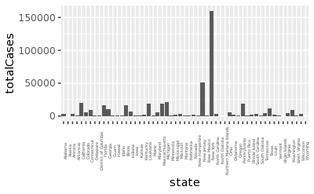

```r
COVIDTotals <- COVID %>%
  filter(date == "2020-04-09") %>%
  group_by(state) %>%
  summarise(totalCases = sum(cases))
COVIDTotals %>%
  ggplot(aes(x = state, y = totalCases)) +
  geom_bar(stat = "identity") +
  theme(axis.text.x = element_text(angle = 90, size = 4))
```

**NOTE:** This plot is technically correct, though it looks a little messy. This is something we will need to correct for the final product!

Next, what PERCENT of each state’s population has COVID-19 (as of 4/9/2020)?

```r
StatePops <- Demographics %>%
  filter(AGEGRP == 0) %>%
  group_by(STNAME) %>%
  summarise(StatePop = sum(TOT_POP))
COVIDPercent <- StatePops %>%
  inner_join(COVIDTotals, by = c("STNAME" = "state")) %>%
  mutate(percent = round((totalCases/StatePop)*100, digits = 4))
```

```
Column `STNAME`/`state` joining factors with different levels, coercing to character vector
```

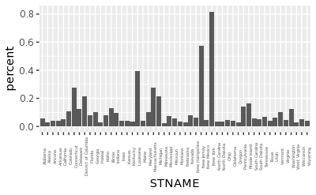

```r
COVIDPercent %>%
  ggplot(aes(x = STNAME, y = percent)) +
  geom_bar(stat = "identity") +
  theme(axis.text.x = element_text(angle = 90, size = 4))
```